# Teradata

Nikhil Bhatewara

April 25, 2018

## work space

```r
### Import libraries
library("plyr")
require("stats")
require("ggplot2")
library("stringdist")
library("dplyr")
library("stringr")
#require("scales")
#workingdirectory <- "D:\\e\\Osu\\Spring 2018\\R_python\\teradata\\working\\cleandata"
workingdirectory="C:\\Users\\msis5223user\\Documents\\teradata_nikhil"
setwd(workingdirectory)
eventsbike_clean <- read.csv("eventsbike_clean.csv")
#summary(eventsbike_clean)
eventsbike_clean <- subset(eventsbike_clean, select = -c(X))




eventsbike_clean[,c(3,4,13,14,27,28,29,21)] <- sapply(eventsbike_clean[,c(3,4,13,14,27,28,29,21)],tolower)
```

- Creating a column “Goal_Achieved” which represents % of goal achieved in each event

```r
df0 <- eventsbike_clean[order(-eventsbike_clean$Total_of_All_Confirmed_Gifts),]
df0$Goal_Achieved<-ifelse(df0$Event_Goal==0, 101, (100*(df0$Total_of_All_Confirmed_Gifts/df0$Event_Goal)))
```

Extracting those events which achieved target goal by more than 80%, excluding those events which have goal events < 1

```r
morethan80percent <- (df0$Goal_Achieved > 80 & df0$Event_Goal>1 )
top80events <- df0[morethan80percent,c(2, 7,11,33)]
```

Similarly extracting those events which did not perform well , target goal achieved less than 30%

```r
lessthan30percent <- (df0$Goal_Achieved < 30 & df0$Event_Goal>1 )
worst30events <- df0[lessthan30percent,c(2, 7,11,33)]
```

# Analysis on TOP 80% STATES

```r
df1 <- df0[df0$Event_ID %in% top80events$Event_ID,c(1,2,27,28,29,30,33)]
```

- TOP 5 STATES BY NUMBER OF EVENTS HAVING > 80 % GOAL ACHIEVED

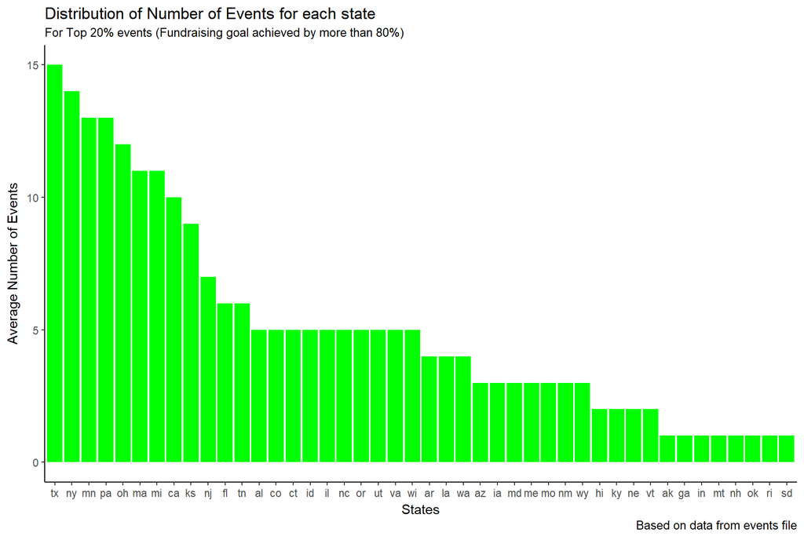

```r
temp1<-plyr::count(df1,"State")
#head(temp1[order(-temp1$freq),],n=5)
ga7 <- (ggplot(temp1,aes(x=reorder(State,-freq),y=freq))+geom_bar(stat='identity',fill='green') + theme_classic())

ga7 + labs(y = "Average Number of Events",x="States",title="Distribution of Number of Events for each state",subtitle="For Top 20% events (Fundraising goal achieved by more than 80%)",caption="Based on data from events file") +guides(fill=FALSE)
```

- TOP 5 STATES BY AVERAGE % GOAL ACHIEVED

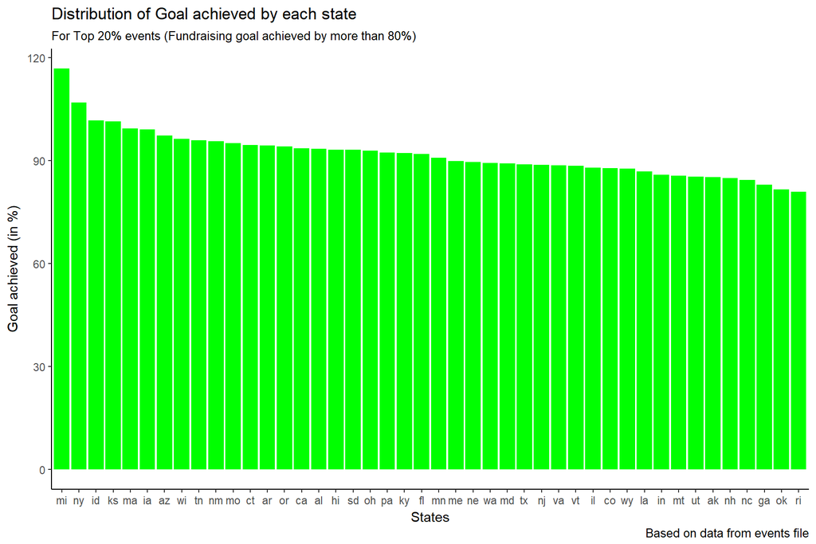

```r
temp2 <- aggregate(Goal_Achieved~State,data=df1,mean)
#head(temp2[order(-temp2$Goal_Achieved),],n=5)
ga8 <- (ggplot(temp2,aes(x=reorder(State,-Goal_Achieved),y=Goal_Achieved))+geom_bar(stat='identity',fill='green') + theme_classic())

ga8 + labs(y = "Goal achieved (in %)",x="States",title="Distribution of Goal achieved by each state",subtitle="For Top 20% events (Fundraising goal achieved by more than 80%)",caption="Based on data from events file") +guides(fill=FALSE)
```

TX,NY,MN,PA,OH,MI,ID,KS,MA are best performing states and should be retained.

Invest more on less performing states

# Analysis on BOTTOM 30% STATES

```r
df2 <- df0[df0$Event_ID %in% worst30events$Event_ID,c(1,2,28,29,30,33)]
```

- TOP 5 STATES BY NUMBER OF EVENTS HAVING < 30 % GOAL ACHIEVED

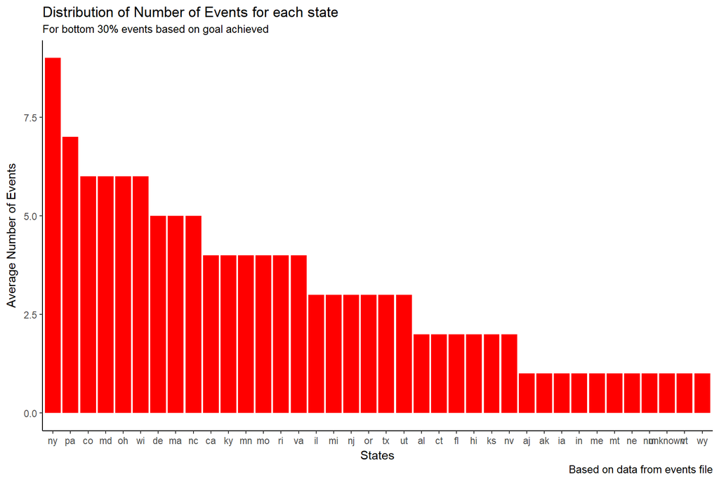

```r
temp3<-plyr::count(df2,"State")
#head(temp3[order(-temp3$freq),],n=5)

ga9 <- (ggplot(temp3,aes(x=reorder(State,-freq),y=freq))+geom_bar(stat='identity',fill='red') + theme_classic())

ga9 + labs(y = "Average Number of Events",x="States",title="Distribution of Number of Events for each state",subtitle="For bottom 30% events based on goal achieved",caption="Based on data from events file") +guides(fill=FALSE)
```

- TOP 5 STATES BY AVERAGE % GOAL ACHIEVED

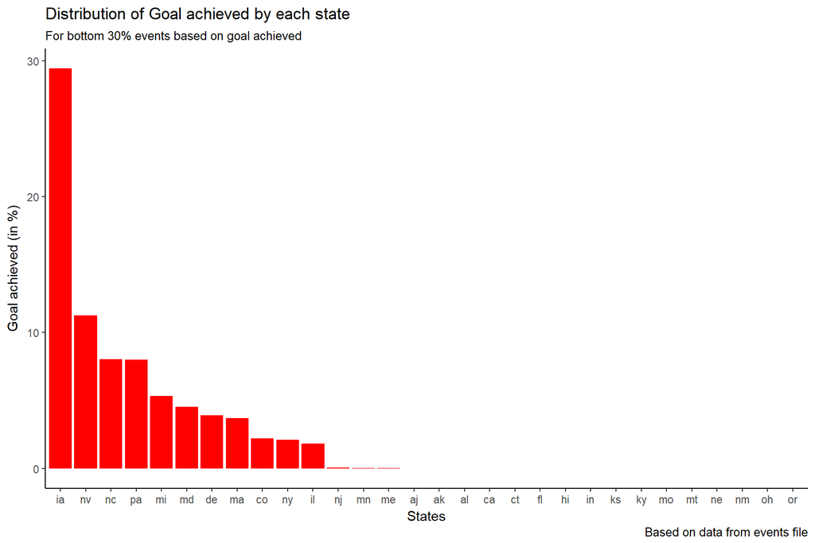

```r
temp4 <- aggregate(Goal_Achieved~State,data=df2,mean)
#head(temp4[order(-temp4$Goal_Achieved),],n=5)

ga10 <- (ggplot(temp4[1:30,],aes(x=reorder(State,-Goal_Achieved),y=Goal_Achieved))+geom_bar(stat='identity',fill='red') + theme_classic())

ga10 + labs(y = "Goal achieved (in %)",x="States",title="Distribution of Goal achieved by each state",subtitle="For bottom 30% events based on goal achieved",caption="Based on data from events file") +guides(fill=FALSE)
```

## Notice that NY,PA,OH are part of both list. So these have both successfull events as well as failed events. Reallocate these resources to top 80%

# TOP event ids from top80perc events

```r
top80eventsdf <- df0[df0$Event_ID %in% top80events$Event_ID, ]
```